# Health Product User Analaysis

```r
library(gridExtra)
```

[output not shown]

## 2. Data cleaning

|  | Id | Date |
| --- | --- | --- |
| 162 | 4388161847 | 2016-05-05 |
| 224 | 4702921684 | 2016-05-07 |
| 381 | 8378563200 | 2016-04-25 |

[output not shown]

```r
df.sleep[which(df.sleep$Id == 4388161847 & df.sleep$Date == '2016-05-05'), ]

df.sleep[which(df.sleep$Id == 4702921684 & df.sleep$Date == '2016-05-07'), ]
```

|  | Id | Date | TotalSleepRecords | TotalMinutesAsleep | TotalTimeInBed |
| --- | --- | --- | --- | --- | --- |
| 223 | 4702921684 | 2016-05-07 | 1 | 520 | 543 |
| 224 | 4702921684 | 2016-05-07 | 1 | 520 | 543 |

```r
df.sleep[which(df.sleep$Id == 8378563200 & df.sleep$Date == '2016-04-25'), ]
```

|  | Id | Date | TotalSleepRecords | TotalMinutesAsleep | TotalTimeInBed |
| --- | --- | --- | --- | --- | --- |
| 380 | 8378563200 | 2016-04-25 | 1 | 388 | 402 |
| 381 | 8378563200 | 2016-04-25 | 1 | 388 | 402 |

```r
df.sleep = df.sleep[!duplicated(df.sleep[, 1:2]), ]
dim(df.sleep)
```

```
[1] 410   5
```

| Id | Date | TotalSteps | TotalDistance | TrackerDistance | LoggedActivitiesDistance | VeryActiveDistance | ModeratelyActiveDistance | LightActiveDistance | SedentaryActiveDistance | VeryActiveMinutes | FairlyActiveMinutes | LightlyActiveMinutes | SedentaryMinutes | Calories | TotalSleepRecords | TotalMinutesAsleep | TotalTimeInBed |
| --- | --- | --- | --- | --- | --- | --- | --- | --- | --- | --- | --- | --- | --- | --- | --- | --- | --- |
| 1503960366 | 2016-04-12 | 13162 | 8.50 | 8.50 | 0.000000 | 1.88 | 0.55 | 6.06 | 0.00 | 25 | 13 | 328 | 728 | 1985 | 1 | 327 | 346 |
| 1503960366 | 2016-04-13 | 10735 | 6.97 | 6.97 | 0.000000 | 1.57 | 0.69 | 4.71 | 0.00 | 21 | 19 | 217 | 776 | 1797 | 2 | 384 | 407 |
| 1503960366 | 2016-04-14 | 10460 | 6.74 | 6.74 | 0.000000 | 2.44 | 0.40 | 3.91 | 0.00 | 30 | 11 | 181 | 1218 | 1776 | NA | NA | NA |
| 1503960366 | 2016-04-15 | 9762 | 6.28 | 6.28 | 0.000000 | 2.14 | 1.26 | 2.83 | 0.00 | 29 | 34 | 209 | 726 | 1745 | 1 | 412 | 442 |
| 1503960366 | 2016-04-16 | 12669 | 8.16 | 8.16 | 0.000000 | 2.71 | 0.41 | 5.04 | 0.00 | 36 | 10 | 221 | 773 | 1863 | 2 | 340 | 367 |
| 1503960366 | 2016-04-17 | 9705 | 6.48 | 6.48 | 0.000000 | 3.19 | 0.78 | 2.51 | 0.00 | 38 | 20 | 164 | 539 | 1728 | 1 | 700 | 712 |
| 1503960366 | 2016-04-18 | 13019 | 8.59 | 8.59 | 0.000000 | 3.25 | 0.64 | 4.71 | 0.00 | 42 | 16 | 233 | 1149 | 1921 | NA | NA | NA |
| 1503960366 | 2016-04-19 | 15506 | 9.88 | 9.88 | 0.000000 | 3.53 | 1.32 | 5.03 | 0.00 | 50 | 31 | 264 | 775 | 2035 | 1 | 304 | 320 |
| 1503960366 | 2016-04-20 | 10544 | 6.68 | 6.68 | 0.000000 | 1.96 | 0.48 | 4.24 | 0.00 | 28 | 12 | 205 | 818 | 1786 | 1 | 360 | 377 |
| 1503960366 | 2016-04-21 | 9819 | 6.34 | 6.34 | 0.000000 | 1.34 | 0.35 | 4.65 | 0.00 | 19 | 8 | 211 | 838 | 1775 | 1 | 325 | 364 |

[output cut: 930 more lines]

## 3. Exploratory analysis

### Question1: How many steps would be required to burn 100 calories?

`r # Scatter plot to visualize relationships df.clean %>% select(c('TotalSteps', 'Calories')) %>% drop_na() %>% ggplot(aes(x=TotalSteps, y=Calories)) + geom_point() + labs(title='How correlated steps and calories burnt?')`

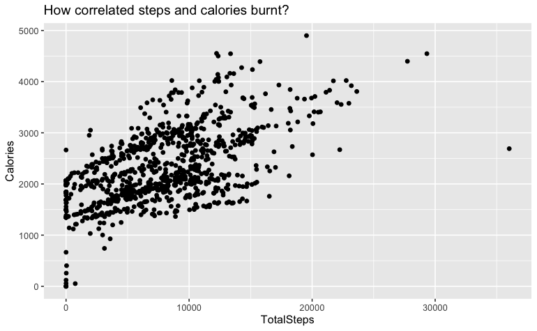

`r df.clean %>% select(c(TotalSteps, TotalDistance, Calories)) %>% cor()`

`TotalSteps TotalDistance Calories TotalSteps 1.0000000 0.9853688 0.5915681 TotalDistance 0.9853688 1.0000000 0.6449619 Calories 0.5915681 0.6449619 1.0000000`

There is moderately positive correlation between steps and calories. It is obvious that steps and distance are highly correlated.

`r # Using linear regression # One particular outlier found deviating the trend - so remove steps > 30000 df.clean %>% filter(TotalSteps<30000) %>% drop_na() %>% lm(formula=Calories~TotalSteps) %>% summary()`

[output not shown]

Therefore, on average across the users in the data, it would require 1323 steps to burn 100 calories. Assumption holds that there is a casual relationship between steps and calories - which makes sense intuitively.

---
### Question2: Does degree of activities/distance influence calories burnt?


```r
# Plot the relationship between distances of 4 different activity types and calories
# p1. calories vs very active distance
p1.dist = ggplot(df.clean, aes(x=VeryActiveDistance, y=Calories)) +
  geom_point(color='black') +
  geom_smooth(method='loess', color='red')

# p2. calories vs moderately active distance
p2.dist = ggplot(df.clean, aes(x=ModeratelyActiveDistance, y=Calories)) +
  geom_point(color='black') +
  geom_smooth(method='loess', color='orange')

# p3. calories vs lightly active distance
p3.dist = ggplot(df.clean, aes(x=LightActiveDistance, y=Calories)) +
  geom_point(color='black') +
  geom_smooth(method='loess', color='yellow')

# p4. calories vs sedentary distance
p4.dist = ggplot(df.clean, aes(x=SedentaryActiveDistance, y=Calories)) +
  geom_point(color='black') +
  geom_smooth(method='loess', color='green')

# Combine plots
# install.packages('gridExtra')
library(gridExtra)
````

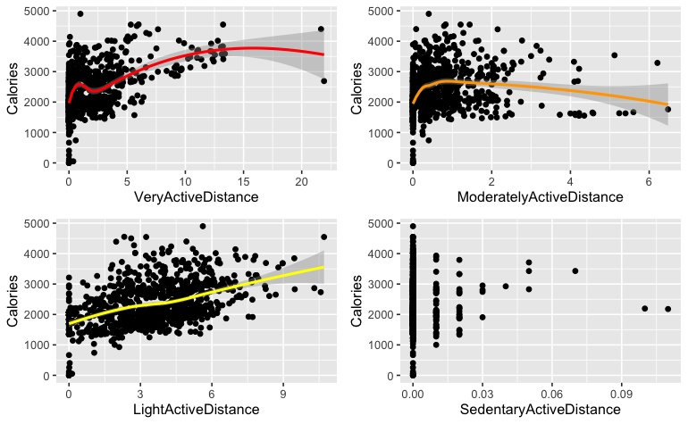

```r
grid.arrange(p1.dist, p2.dist, p3.dist, p4.dist, nrow=2)
```

There is a negative trend between `moderately active distance` and `calories burnt`, which is not intuitive. Seeing the graph, this trend is resulted by some outliers (more than 3.5 KM over 1500-2000 calories burnt). It may be worth checking what they are - in the following section.

On the other hand, trend is not obvious between `sedentary active distance` and `calories burnt` very likely due to high concentration of zero values (no sedentary activity).

Let’s plot the minutes vs calories to see if the trend draws the similar trend lines.

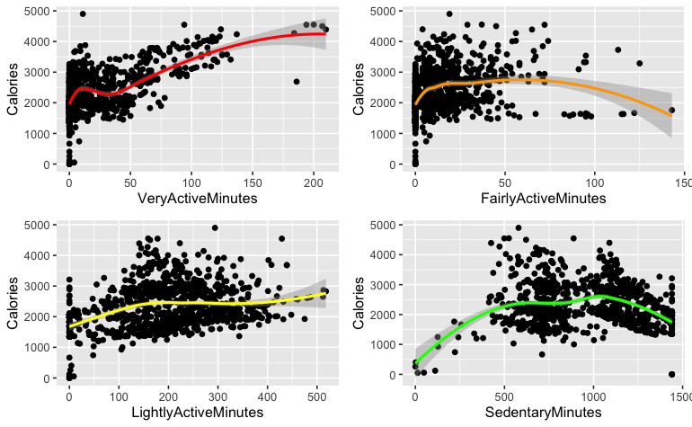

```r
# Plot the relationship between minutes of 4 different activity types and calories
# p1. calories vs very active minutes
p1.min = ggplot(df.clean, aes(x=VeryActiveMinutes, y=Calories)) +
  geom_point(color='black') +
  geom_smooth(method='loess', color='red')

# p2. calories vs fairly active minutes
p2.min = ggplot(df.clean, aes(x=FairlyActiveMinutes, y=Calories)) +
  geom_point(color='black') +
  geom_smooth(method='loess', color='orange')

# p3. calories vs lightly active minutes
p3.min = ggplot(df.clean, aes(x=LightlyActiveMinutes, y=Calories)) +
  geom_point(color='black') +
  geom_smooth(method='loess', color='yellow')

# p4. calories vs sedentary minutes
p4.min = ggplot(df.clean, aes(x=SedentaryMinutes, y=Calories)) +
  geom_point(color='black') +
  geom_smooth(method='loess', color='green')

# Combine plots
# install.packages('gridExtra')
# library(gridExtra)
grid.arrange(p1.min, p2.min, p3.min, p4.min, nrow=2)
```

`Moderately active (or Fairly active) minutes` still show a negative trend line, very likely due to the outliers. It is interesting to observe that `sedentary minutes` and `calories` now show a trend thanks to a few data marking non-zero values. It is suspicious now that the health device may not be measuring sedentary distances in a correct manner. Let’s also take a look at it.

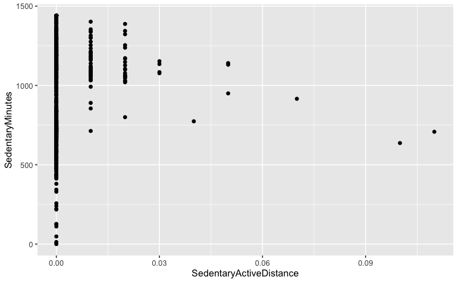

```r
# It should have a positive linear trend, or there is something wrong
df.clean %>%
  ggplot(aes(x=SedentaryActiveDistance, y=SedentaryMinutes)) + geom_point()
```

The graph clearly shows that the device captured minute records up to 1500 minutes despite zero distance recorded. Those records account for 91.3% of the total records, which is seriously wrong. It makes more sense that we use minutes variables instead of distance variables.

```r
df.clean %>%
  filter(SedentaryActiveDistance==0) %>%
  nrow() / nrow(df.clean)
```

```
[1] 0.9130435
```

Let’s now inspect outliers that make moderate active vs calories negative trend. Outliers is characterized more than 75 minutes moderate(fairly) active over 1500-2000 calories burnt.

```r
df.clean %>%
  filter(FairlyActiveMinutes>75 & Calories > 1500 & Calories < 2000) # 13 records
```

| Id | Date | TotalSteps | TotalDistance | TrackerDistance | LoggedActivitiesDistance | VeryActiveDistance | ModeratelyActiveDistance | LightActiveDistance | SedentaryActiveDistance | VeryActiveMinutes | FairlyActiveMinutes | LightlyActiveMinutes | SedentaryMinutes | Calories | TotalSleepRecords | TotalMinutesAsleep | TotalTimeInBed |
| --- | --- | --- | --- | --- | --- | --- | --- | --- | --- | --- | --- | --- | --- | --- | --- | --- | --- |
| 3977333714 | 2016-04-16 | 13459 | 9.00 | 9.00 | 0 | 2.03 | 4.00 | 2.97 | 0 | 31 | 83 | 153 | 663 | 1625 | 1 | 283 | 510 |
| 3977333714 | 2016-04-18 | 11663 | 7.80 | 7.80 | 0 | 0.25 | 3.73 | 3.82 | 0 | 4 | 95 | 214 | 605 | 1584 | 2 | 412 | 522 |
| 3977333714 | 2016-04-20 | 11658 | 7.83 | 7.83 | 0 | 0.20 | 4.35 | 3.28 | 0 | 2 | 98 | 164 | 845 | 1554 | 2 | 152 | 305 |
| 3977333714 | 2016-04-23 | 12058 | 8.07 | 8.07 | 0 | 0.00 | 4.22 | 3.85 | 0 | 0 | 92 | 252 | 724 | 1638 | 1 | 235 | 372 |
| 3977333714 | 2016-04-24 | 14112 | 10.00 | 10.00 | 0 | 3.27 | 4.56 | 2.17 | 0 | 30 | 95 | 129 | 660 | 1655 | 1 | 310 | 526 |
| 3977333714 | 2016-04-26 | 11388 | 7.62 | 7.62 | 0 | 0.45 | 4.22 | 2.95 | 0 | 7 | 95 | 170 | 797 | 1551 | 1 | 250 | 371 |
| 3977333714 | 2016-05-02 | 16520 | 11.05 | 11.05 | 0 | 1.54 | 6.48 | 3.02 | 0 | 24 | 143 | 176 | 713 | 1760 | 1 | 230 | 384 |
| 3977333714 | 2016-05-04 | 13559 | 9.44 | 9.44 | 0 | 1.81 | 4.58 | 2.89 | 0 | 14 | 96 | 142 | 852 | 1628 | 1 | 213 | 336 |
| 3977333714 | 2016-05-05 | 12312 | 8.58 | 8.58 | 0 | 1.76 | 4.11 | 2.71 | 0 | 14 | 88 | 178 | 680 | 1618 | 1 | 318 | 480 |
| 3977333714 | 2016-05-07 | 11550 | 7.73 | 7.73 | 0 | 0.00 | 4.13 | 3.59 | 0 | 0 | 86 | 208 | 703 | 1574 | 1 | 237 | 443 |

[output cut: 3 more lines]

It appears that the outliers are from 13 records from one particular user with the id #3977333714. Let’s inspect this person.

```r
df.clean %>%
  filter(Id == 3977333714) %>%
  select(c(1, 3, 4, 11: ncol(df.clean))) %>%
  summary()
```

```
       Id              TotalSteps    TotalDistance    VeryActiveMinutes FairlyActiveMinutes LightlyActiveMinutes SedentaryMinutes    Calories    TotalSleepRecords TotalMinutesAsleep TotalTimeInBed
 Min.   :3.977e+09   Min.   :  746   Min.   : 0.500   Min.   : 0.00     Min.   :  0.00      Min.   :  9.0        Min.   :  13.0   Min.   :  52   Min.   :1.000     Min.   :152.0      Min.   :305.0
 1st Qu.:3.977e+09   1st Qu.: 9266   1st Qu.: 6.223   1st Qu.: 4.25     1st Qu.: 25.25      1st Qu.:151.5        1st Qu.: 676.0   1st Qu.:1484   1st Qu.:1.000     1st Qu.:246.8      1st Qu.:396.5
 Median :3.977e+09   Median :11604   Median : 7.815   Median :14.50     Median : 56.50      Median :176.0        Median : 712.5   Median :1572   Median :1.000     Median :291.5      Median :468.0
 Mean   :3.977e+09   Mean   :10985   Mean   : 7.517   Mean   :18.90     Mean   : 61.27      Mean   :174.8        Mean   : 707.5   Mean   :1514   Mean   :1.143     Mean   :293.6      Mean   :461.1
 3rd Qu.:3.977e+09   3rd Qu.:13196   3rd Qu.: 8.945   3rd Qu.:31.00     3rd Qu.: 95.00      3rd Qu.:202.8        3rd Qu.: 771.2   3rd Qu.:1632   3rd Qu.:1.000     3rd Qu.:332.2      3rd Qu.:512.0
 Max.   :3.977e+09   Max.   :16520   Max.   :11.050   Max.   :50.00     Max.   :143.00      Max.   :258.0        Max.   :1159.0   Max.   :1760   Max.   :2.000     Max.   :424.0      Max.   :626.0
                                                                                                                                                 NA's   :2         NA's   :2          NA's   :2
```

```r
df.clean %>%
  filter(Id != 3977333714) %>%
  select(c(1, 3, 4, 11: ncol(df.clean))) %>%
  summary()
```

```
       Id              TotalSteps    TotalDistance    VeryActiveMinutes FairlyActiveMinutes LightlyActiveMinutes SedentaryMinutes    Calories    TotalSleepRecords TotalMinutesAsleep TotalTimeInBed
 Min.   :1.504e+09   Min.   :    0   Min.   : 0.000   Min.   :  0.00    Min.   :  0.00      Min.   :  0.0        Min.   :   0.0   Min.   :   0   Min.   :1.000     Min.   : 58.0      Min.   : 61.0
 1st Qu.:2.320e+09   1st Qu.: 3727   1st Qu.: 2.600   1st Qu.:  0.00    1st Qu.:  0.00      1st Qu.:125.0        1st Qu.: 733.0   1st Qu.:1854   1st Qu.:1.000     1st Qu.:380.0      1st Qu.:406.0
 Median :4.559e+09   Median : 7289   Median : 5.180   Median :  3.00    Median :  6.00      Median :200.0        Median :1067.0   Median :2177   Median :1.000     Median :440.0      Median :463.0
 Mean   :4.887e+09   Mean   : 7543   Mean   : 5.437   Mean   : 21.32    Mean   : 12.06      Mean   :193.6        Mean   : 999.6   Mean   :2334   Mean   :1.117     Mean   :428.6      Mean   :458.5
 3rd Qu.:7.008e+09   3rd Qu.:10611   3rd Qu.: 7.570   3rd Qu.: 32.00    3rd Qu.: 18.00      3rd Qu.:268.0        3rd Qu.:1236.0   3rd Qu.:2806   3rd Qu.:1.000     3rd Qu.:498.0      3rd Qu.:530.0
 Max.   :8.878e+09   Max.   :36019   Max.   :28.030   Max.   :210.00    Max.   :125.00      Max.   :518.0        Max.   :1440.0   Max.   :4900   Max.   :3.000     Max.   :796.0      Max.   :961.0
                                                                                                                                                 NA's   :528       NA's   :528        NA's   :528
```

The user with id #3977333714 is identified as the outlier. The person is relatively more active than the others given higher median very active, especially fairly active minutes and higher steps - but calories burnt is not comparatively high. Compared to the other users, the user lacks sleeps (on average less than 5 hours asleep vs 7 hours in general)

Let’s plot again removing this outlier.

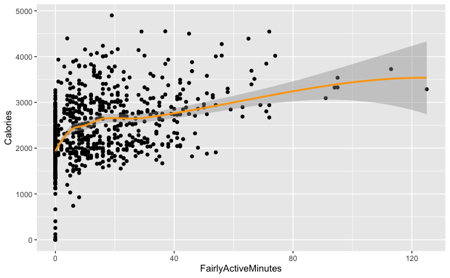

```r
df.clean %>%
  filter(Id != 3977333714) %>%
  ggplot(aes(x=FairlyActiveMinutes, y=Calories)) +
  geom_point(color='black') +
  geom_smooth(method='loess', color='orange')
```

Removing the outlier, tt now shows positive trend between `FairlyActiveMinutes` and `Calories` burnt - which makes more sense.

```r
# Slicing activity and calorie data
# Activity data includes 4 types of activities measured minutes
lm.activity = df.clean %>%
  filter(Id != 3977333714) %>%  # filtering the outlier user
  select(c(11:15)) %>%  # selecting only minutes and calories data
  drop_na() %>%
  lm(formula=Calories~.)

summary(lm.activity)
```

```
Call:
lm(formula = Calories ~ ., data = .)

Residuals:
     Min       1Q   Median       3Q      Max
-2018.87  -389.24   -50.16   360.94  2557.19

Coefficients:
                      Estimate Std. Error t value Pr(>|t|)
(Intercept)          1.392e+03  8.821e+01  15.779  < 2e-16 ***
VeryActiveMinutes    1.175e+01  5.500e-01  21.370  < 2e-16 ***
FairlyActiveMinutes  9.286e+00  1.108e+00   8.383  < 2e-16 ***
LightlyActiveMinutes 1.703e+00  1.715e-01   9.934  < 2e-16 ***
SedentaryMinutes     2.494e-01  6.381e-02   3.909 9.97e-05 ***
---
Signif. codes:  0 ‘***’ 0.001 ‘**’ 0.01 ‘*’ 0.05 ‘.’ 0.1 ‘ ’ 1

Residual standard error: 505.4 on 908 degrees of freedom
Multiple R-squared:  0.5038,    Adjusted R-squared:  0.5016
F-statistic: 230.4 on 4 and 908 DF,  p-value: < 2.2e-16
```

```r
lm.activity$coefficients
```

```
         (Intercept)    VeryActiveMinutes  FairlyActiveMinutes LightlyActiveMinutes     SedentaryMinutes
        1391.8538040           11.7542493            9.2862332            1.7034375            0.2494136
```

The multivariate linear regression model reports the coefficients between activity minutes and calories. It makes sense that the more active the more calories burnt. It is interesting to see a big division between active vs non active when it comes to its effect on burning calories. It implies that to burn calories, just lightly or sedentary activities are not helpful. It is especially true for sedentary activity.

### Question3: How does steps and activities influence sleep time?

`r # Create a new data frame with relevant features df.clean.sleep = df.clean %>% select(c(1, 3, 4, 11: ncol(df.clean)))`

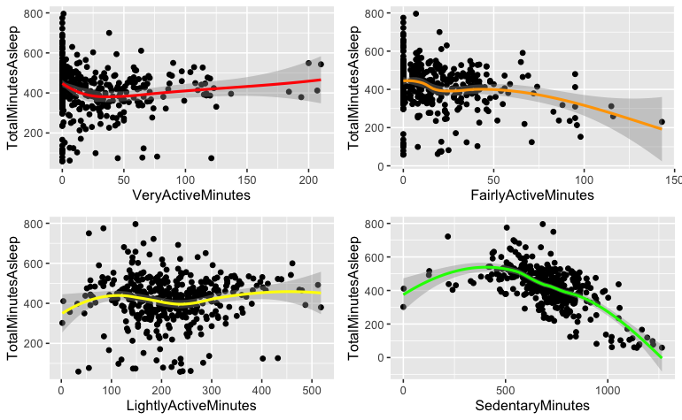

```r df.clean.sleep %>% drop_na() %>% select(c(4:7, 10)) %>% lm(formula=TotalMinutesAsleep~.) %>% summary()

```

[output not shown]

```r
df.clean.sleep %>%
  drop_na() %>%
  select(c(2:7, 10)) %>%
  lm(formula=TotalMinutesAsleep~.) %>%
  summary()
````

```
Call:
lm(formula = TotalMinutesAsleep ~ ., data = .)

Residuals:
    Min      1Q  Median      3Q     Max
-519.31  -41.84    8.59   56.96  325.36

Coefficients:
                       Estimate Std. Error t value Pr(>|t|)
(Intercept)          821.606578  26.151174  31.418  < 2e-16 ***
TotalSteps            -0.009689   0.005785  -1.675   0.0947 .
TotalDistance          8.437809   7.697241   1.096   0.2736
VeryActiveMinutes      0.011975   0.181909   0.066   0.9475
FairlyActiveMinutes   -1.049804   0.256970  -4.085 5.31e-05 ***
LightlyActiveMinutes  -0.109803   0.074814  -1.468   0.1430
SedentaryMinutes      -0.460406   0.027153 -16.956  < 2e-16 ***
---
Signif. codes:  0 ‘***’ 0.001 ‘**’ 0.01 ‘*’ 0.05 ‘.’ 0.1 ‘ ’ 1

Residual standard error: 87.71 on 406 degrees of freedom
Multiple R-squared:  0.4587,    Adjusted R-squared:  0.4507
F-statistic: 57.35 on 6 and 406 DF,  p-value: < 2.2e-16
```

There is not much of improvement in the explainability of variables by adding steps and distance. Also, TotalSteps TotalDistance do not confidently show relationship with sleep time. Let’s now see if intensity can help reduce the time taken to fall asleep (TotalTimeInBed - TotalMinutesAsleep) - the assumption is that the smaller the time, the more quality one’s sleep is.

```r
df.clean.sleep %>%
  drop_na() %>%
  mutate(TimeTakenToSleep = TotalTimeInBed - TotalMinutesAsleep) %>%
  lm(formula=TimeTakenToSleep~VeryActiveMinutes+FairlyActiveMinutes+LightlyActiveMinutes+SedentaryMinutes) %>%
  summary()
```

```
Call:
lm(formula = TimeTakenToSleep ~ VeryActiveMinutes + FairlyActiveMinutes +
    LightlyActiveMinutes + SedentaryMinutes, data = .)

Residuals:
    Min      1Q  Median      3Q     Max
-87.648 -19.219  -6.329   9.197 305.100

Coefficients:
                      Estimate Std. Error t value Pr(>|t|)
(Intercept)          106.92139   12.32584   8.675  < 2e-16 ***
VeryActiveMinutes     -0.32923    0.06065  -5.428 9.79e-08 ***
FairlyActiveMinutes    0.80547    0.09614   8.378 8.76e-16 ***
LightlyActiveMinutes  -0.13686    0.02491  -5.494 6.94e-08 ***
SedentaryMinutes      -0.06221    0.01278  -4.868 1.62e-06 ***
---
Signif. codes:  0 ‘***’ 0.001 ‘**’ 0.01 ‘*’ 0.05 ‘.’ 0.1 ‘ ’ 1

Residual standard error: 41.39 on 408 degrees of freedom
Multiple R-squared:  0.2177,    Adjusted R-squared:   0.21
F-statistic: 28.38 on 4 and 408 DF,  p-value: < 2.2e-16
```

Given the R-squared, intensity of activities alone cannot fully explain the time taken to fall asleep.

### Question4: How does users use the device throughout days of week. Any particular patterns or differences?

```r
# Create day of week variable
df.clean$DayOfWeek = weekdays(df.clean$Date)

# Make it a categorical variable in order
# df.clean$DayOfWeek = factor(df.clean$DayOfWeek, levels= c("Sunday", "Monday",
#     "Tuesday", "Wednesday", "Thursday", "Friday", "Saturday"))
```

| Id_pval | TotalSteps_pval | TotalDistance_pval | TrackerDistance_pval | LoggedActivitiesDistance_pval | VeryActiveDistance_pval | ModeratelyActiveDistance_pval | LightActiveDistance_pval | SedentaryActiveDistance_pval | VeryActiveMinutes_pval | FairlyActiveMinutes_pval | LightlyActiveMinutes_pval | SedentaryMinutes_pval | Calories_pval | TotalSleepRecords_pval | TotalMinutesAsleep_pval | TotalTimeInBed_pval |
| --- | --- | --- | --- | --- | --- | --- | --- | --- | --- | --- | --- | --- | --- | --- | --- | --- |
| 3.469326e-22 | 6.747524e-15 | 2.213914e-20 | 1.596351e-20 | 2.21595e-53 | 2.887866e-41 | 5.109608e-39 | 1.376284e-11 | 2.709527e-52 | 5.215073e-38 | 1.315802e-37 | 3.922208e-11 | 4.89014e-17 | 4.049891e-13 | 2.318768e-35 | 1.923384e-10 | 1.275823e-14 |

According to Shapiro-Wilk’s test, none of the numeric features (i.e. distance, step, activity distance/minute, sleep, etc) are normal. So the aggregation through summary statistics should be carefully performed For example, mean of a feature is not relevent - let’s use median instead.

| Group.1 | TotalSteps | TotalDistance | VeryActiveDistance | ModeratelyActiveDistance | LightActiveDistance | SedentaryActiveDistance | VeryActiveMinutes | FairlyActiveMinutes | LightlyActiveMinutes | SedentaryMinutes | Calories |
| --- | --- | --- | --- | --- | --- | --- | --- | --- | --- | --- | --- |
| Friday | 7408 | 5.080 | 0.075 | 0.210 | 3.460 | 0 | 1.5 | 5.0 | 205.0 | 1065 | 2203.5 |
| Monday | 7726 | 5.240 | 0.630 | 0.290 | 3.730 | 0 | 8.0 | 8.0 | 201.0 | 1081 | 2189.0 |
| Saturday | 6987 | 4.970 | 0.150 | 0.160 | 3.500 | 0 | 3.0 | 4.0 | 223.0 | 1076 | 2132.0 |
| Sunday | 6083 | 4.180 | 0.000 | 0.050 | 2.800 | 0 | 0.0 | 1.0 | 185.0 | 1060 | 2063.0 |
| Thursday | 7885 | 5.365 | 0.165 | 0.270 | 3.370 | 0 | 3.5 | 6.5 | 190.5 | 951 | 2065.5 |
| Tuesday | 8411 | 6.020 | 0.490 | 0.320 | 3.670 | 0 | 7.5 | 8.0 | 209.0 | 1063 | 2229.0 |
| Wednesday | 7317 | 5.410 | 0.335 | 0.275 | 3.205 | 0 | 5.0 | 8.0 | 191.0 | 1053 | 2143.0 |

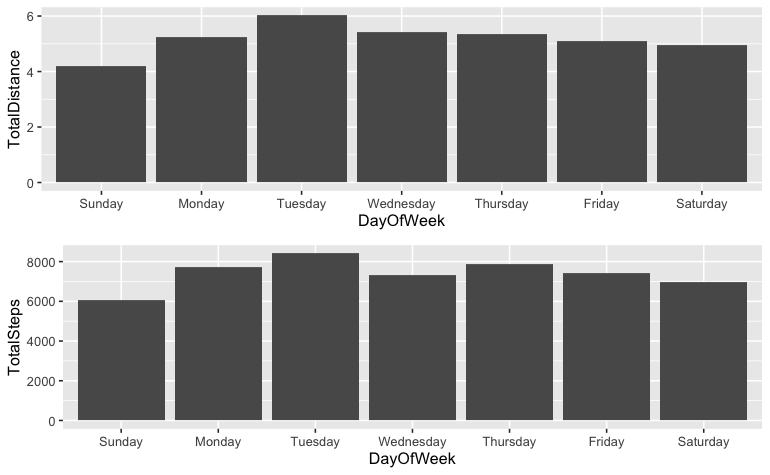

The level of activities peaks on Tuesday and the lowest on Sunday.

## 4. Further Analysis through Clustering

**Methodology:** Hierarchical clustering will firstly be performed and a dendrogram will be plotted to intuitively evaluate the number of clusters needed. KMeans clustering will be followed with the same number of clustering assigned to determine **k** centeroids to be used.

### Preprocessing

Create a new data frame filtering out unnecessary / duplicated variables. To remove

1. The 4 variables related to distances by intensities - to use aggregated `TotalDistance` and the other 4 `ActiveMinutes` variables.
2. `Date` variable as the new data frame will represent numeric variables grouped by individual ids
3. `TrackerDistance` and `LoggedActivitiesDistance` are redundant for our analysis.
4. `TotalTimeInBed` feature will be used to create a new `MinutesToFallSleep` variable and be dropped as it gives no valuable information alone.
5. `TotalSleepRecords` will also be dropped.

```r
df.clustering = df.clean %>%
  mutate(MinutesToFallSleep=TotalTimeInBed-TotalMinutesAsleep) %>% # now 19 variables in total
  select(!c(2, 5:10, 16, 18))

str(df.clustering)
```

```
'data.frame':   940 obs. of  10 variables:
 $ Id                  : num  1.5e+09 1.5e+09 1.5e+09 1.5e+09 1.5e+09 ...
 $ TotalSteps          : int  13162 10735 10460 9762 12669 9705 13019 15506 10544 9819 ...
 $ TotalDistance       : num  8.5 6.97 6.74 6.28 8.16 ...
 $ VeryActiveMinutes   : int  25 21 30 29 36 38 42 50 28 19 ...
 $ FairlyActiveMinutes : int  13 19 11 34 10 20 16 31 12 8 ...
 $ LightlyActiveMinutes: int  328 217 181 209 221 164 233 264 205 211 ...
 $ SedentaryMinutes    : int  728 776 1218 726 773 539 1149 775 818 838 ...
 $ Calories            : int  1985 1797 1776 1745 1863 1728 1921 2035 1786 1775 ...
 $ TotalMinutesAsleep  : int  327 384 NA 412 340 700 NA 304 360 325 ...
 $ MinutesToFallSleep  : int  19 23 NA 30 27 12 NA 16 17 39 ...
```

Now aggregate the numeric variables by `Id`. As we observed that all the numeric features are skewed. Therefore, we will represent **median** values. There are 9 Ids that do not have sleep data at all so filling NA values is not possible - as the original `df.sleep` data had contain records from 24 ids. Let’s firstly conduct a clustering without sleep data, which means we will exclude sleep variables so all 33 ids can be used. As it will mostly contains activity data, save it as `df.grouped.activity`

```r
df.grouped.activity = df.clustering %>% select(!c(TotalMinutesAsleep, MinutesToFallSleep))
df.grouped.activity = df.grouped.activity %>% aggregate(by=list(df.grouped.activity$Id), median)

# Inspect the dataset
dim(df.grouped.activity) # should have 33 unique ids
```

```
[1] 33  9
```

```r
sum(!complete.cases(df.grouped.activity)) # no missing values
```

```
[1] 0
```

Clustering algorithms performs bad on data with different scales so standardising the data is important.

```r
# Re-scaling dataset
df.grouped.activity.scaled = scale(df.grouped.activity)

# view(df.grouped.activity.scaled)
# Remove unncessary columns
df.grouped.activity.scaled %>% select(!c(1:2))
```

[output not shown]

### Hierarchical clustering (agglomerative - bottom up)

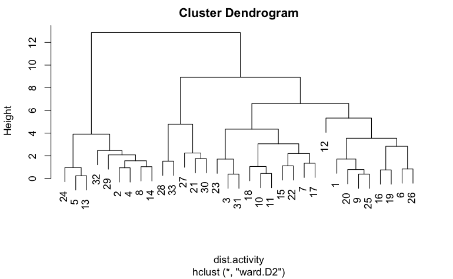

The height represents the degree of distance between clusters. Intuitively base don the visualization, grouping with 5 clusters are reasonable - note that there is an potential outlier (labled as 12).

```r
table(df.grouped.activity$SegHclust) # Cluste
```

```
 1  2  3  4  5
 8  9 10  1  5
```

```r
df.grouped.activity[df.grouped.activity$SegHclust == 4, 'Id'] # Id = 3977333714
```

```
[1] 3977333714
```

Remember that the #Id 3977333714 is the user that was classified as an outlier in the previous descriptive analysis. This user spent more minutes staying fairly active but did not burn comparatively enough calories than others - the user lacked sleeps as well. By removing this user, the relationship activity and calories was clearer. By keeping this outlier information in mind, let’s review the segementation report as below:

| Group.1 | TotalDistance | VeryActiveMinutes | FairlyActiveMinutes | LightlyActiveMinutes | SedentaryMinutes | Calories | SegHclust | TotalMinutes |
| --- | --- | --- | --- | --- | --- | --- | --- | --- |
| 1 | 7.440 | 18.5 | 15.5 | 253.5 | 768.00 | 2300.25 | 1 | 1041.5 |
| 2 | 1.480 | 0.0 | 0.0 | 87.0 | 1288.00 | 1934.00 | 2 | 1422.0 |
| 3 | 4.880 | 1.5 | 3.5 | 270.5 | 1081.75 | 2185.50 | 3 | 1382.5 |
| 4 | 7.815 | 14.5 | 56.5 | 176.0 | 712.50 | 1572.00 | 4 | 959.5 |
| 5 | 6.810 | 68.0 | 10.0 | 158.0 | 761.00 | 3389.50 | 5 | 983.5 |

Each segment is expected to have a distinctive property from the others. Let’s take a closer look:

By `SegHclust`: - 1: ‘Active users’ who stay fairly active but less likely to spend time in sedentary activities. Although total activity minutes are comparatively low, total steps and distance (therefore calories burnt) are high, which proves that they often engage in more intense activities. - 2: ‘Inactive users’ who enjoy wearing the device but most likely engage in light / sedentary activities - no active minutes reported and total distance and steps are noticeably lower than the other segments. - 3: ‘Light users’ who are mostly likely spending time lightly active / sedentary but spare some time for more intense activities which differentiate them from ‘inactive’ users. - 4: Represents a particular user #3977333714, fairly active but calories burnt is the lowest possibly due to insufficient total activity minutes. Ironically, total steps and Total distance are comparatively high so it is suspicious that the activity minutes are not correctly captured by the device. - 5: ‘Power users’ who largely very/fairly active. Steps and distance are very high and burnt lots of calories every day. Total minutes are not the highest which may indicate that the user does not wear the device as often when engaging in lighter activities.

Let’s map the description onto the cluster numbers.

```r
# Instantiate a column to map
df.grouped.activity$SegHclustLabel = NA

# Map with number in 'SegHclust' with labels
df.grouped.activity$SegHclustLabel[which(df.grouped.activity$SegHclust == 1)]
```

```
[1] NA NA NA NA NA NA NA NA
```

As there are many variables, to represent the relationship in 2D plot, let’s use two correlated variables: total steps and calories. The grouping is fairly distinctive but with noise, attributed to the low sample size (33 Ids only).

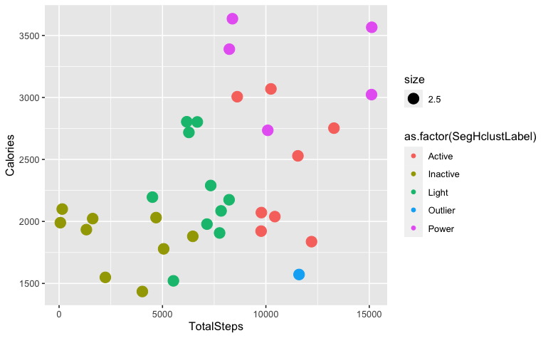

### Kmeans clustering

| Group.1 | TotalDistance | VeryActiveMinutes | FairlyActiveMinutes | LightlyActiveMinutes | SedentaryMinutes | Calories | SegHclust |
| --- | --- | --- | --- | --- | --- | --- | --- |
| 1 | 4.5100 | 1.00 | 5.0 | 159.75 | 1228.0 | 2374.50 | 2.5 |
| 2 | 7.8150 | 18.00 | 16.0 | 253.00 | 761.0 | 2529.00 | 1.0 |
| 3 | 8.6600 | 77.25 | 9.0 | 158.25 | 928.0 | 3477.75 | 5.0 |
| 4 | 5.2100 | 1.50 | 3.5 | 285.00 | 740.0 | 2031.75 | 3.0 |
| 5 | 1.0025 | 0.00 | 0.0 | 48.50 | 1348.5 | 1962.00 | 2.0 |

Let’s look at the plot first to see the grouping more clearly.

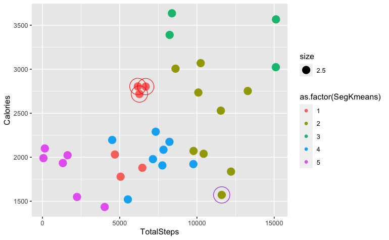

Note that the outlier (circled in purple) is part of Segment 2 in KMeans clusters. Some noise are still found (i.e. 3 records circled in red that belongs to Segment 1). Let’s try with 4 centerfolds, hoping to ignore an outlier and get more seperative clusters.

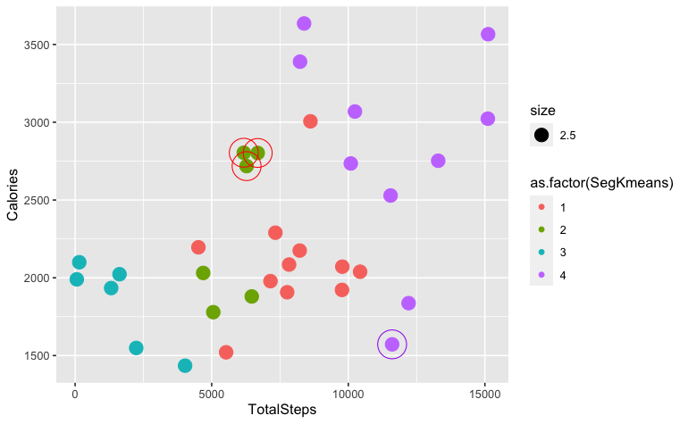

Characteristics of ‘power users’ are less obvious when k=4, whereas the noise (i.3. 3 red circled points) still exist. It looks that hierarchical clustering resulted in a clearer representation, but let’s perform a silhouette test on KMeans clustering to see if we can find the optimal k (# centeroids).

The below code is inspired by a [post on medium](https://medium.com/codesmart/r-series-k-means-clustering-silhouette-794774b46586).

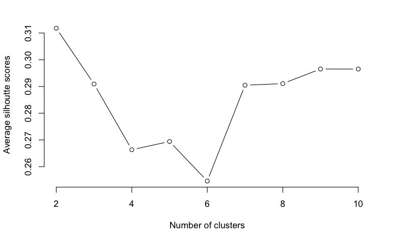

The values from Silhouette scores range from -1 to 1 where a high value indicates that the data point is well matched to its own cluster. It looks that using 2 clusters is the optimal but practically speaking then clustering is not useful. On the other hands, too many clusters given the small sample size (33 ids) are not equally useful as each cluster then will be characterized from a few data points only. In a practical point of view, grouping by 4-5 clusters still make sense.

For the particular dataset, between the two clustering methods, hierarchical clustering provides clearer representation of clusters, which also successfully classifies an outlier. More data examples and features (including demographics for example) may be more helpful to divide groups.